# Weights of chicks

In this example you will analyse a data set of chick weights using a hierarchical GAM.

Start by loading the packages that you’ll need

```r
pkgs <- c(
  "mgcv", "gratia", "ggplot2", "dplyr", "janitor", "marginaleffects"
)
vapply(
  pkgs, library, logical(1),
  character.only = TRUE, logical.return = TRUE
)
```

```
           mgcv          gratia         ggplot2           dplyr         janitor
           TRUE            TRUE            TRUE            TRUE            TRUE
marginaleffects
           TRUE
```

and then load the data. The data are an example data set that comes with R, so we load it using `data()` and then make it tidy

```r
data(ChickWeight)
cw <- ChickWeight |>
  as_tibble() |>
  janitor::clean_names()
cw
```

```
# A tibble: 578 × 4
   weight  time chick diet
    <dbl> <dbl> <ord> <fct>
 1     42     0 1     1
 2     51     2 1     1
 3     59     4 1     1
 4     64     6 1     1
 5     76     8 1     1
 6     93    10 1     1
 7    106    12 1     1
 8    125    14 1     1
 9    149    16 1     1
10    171    18 1     1
# ℹ 568 more rows
```

**NoteTask**

Fit a factor `by` model to the data in order to model the time-structured treatment mean effects only. We’ll ignore the repeated measures aspect of the data for now.

**TipSolution**

```r
m_cw_by <- gam(
  weight ~
    diet + # parametric effect of treatment means
    s(time, by = diet), # smooths of time effect per treatment level
  data = cw, family = tw(), method = "REML"
)
```

**NoteTask**

Fit a similar model to the chick weight data, but this time include an average smooth effect of `time` and `diet`-specific deviation smooths using the constrained factor smooth basis.

**TipSolution**

```r
m_cw_sz <- gam(
  weight ~
    s(time) + # average smooth
    s(time, diet, bs = "sz"), # smooths of time effect per treatment level
  data = cw, family = tw(), method = "REML"
)
```

**NoteTask**

We realise we should account for the repeated measures nature of the data. How would you modify the last model to include a random intercept (effect) for `chick`?

**TipSolution**

```r
m_cw_sz <- gam(
  weight ~
    s(time) + # average smooth
    s(time, diet, bs = "sz") + # smooths of time effect per treatment level
    s(chick, bs = "re"), # random intercept per chick
  data = cw, family = tw(), method = "REML"
)
```

**NoteTask**

You think that it would be better to include in the model terms for the growth curve of each chick, instead of using a random intercept to induce a correlation among the observations of individual chicks. How would you achieve this?

Note: You’ll likely want to use `bam()` to fit this model, with `method = "fREML"` and `discrete = TRUE` to speed things up, so fitting doesn’t take a few minutes.

**TipSolution**

```r
m_cw_fs <- bam(
  weight ~
    s(time) + # average smooth
    s(time, diet, bs = "sz") + # smooths of time effect per treatment level
    s(time, chick, bs = "fs"), # random smooths per chick
  data = cw, family = tw(), method = "fREML", discrete = TRUE
)
```

**NoteTask**

Using this final model, prepare a plot of the estimated treatment (`diet`) effects.

**TipSolution**

We can do this with `conditional_values()`

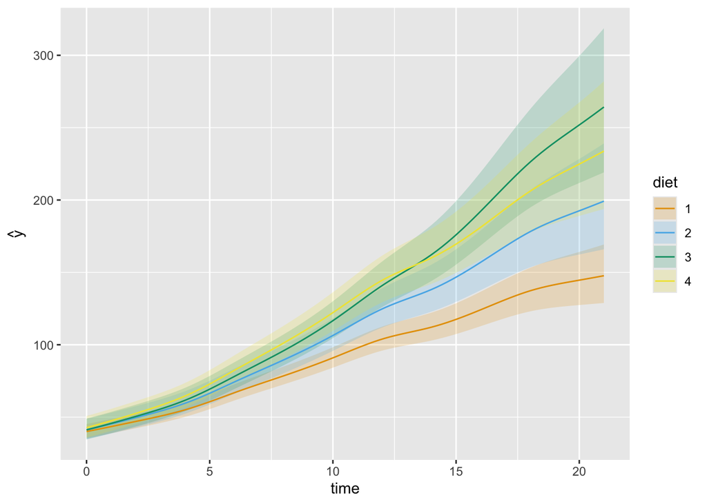

```r
m_cw_fs |>
  conditional_values(
    condition = c("time", "diet"),
    exclude = "s(time,chick)"
  ) |>
  draw()
```

Or with `marginaleffects::plot_predictions()`

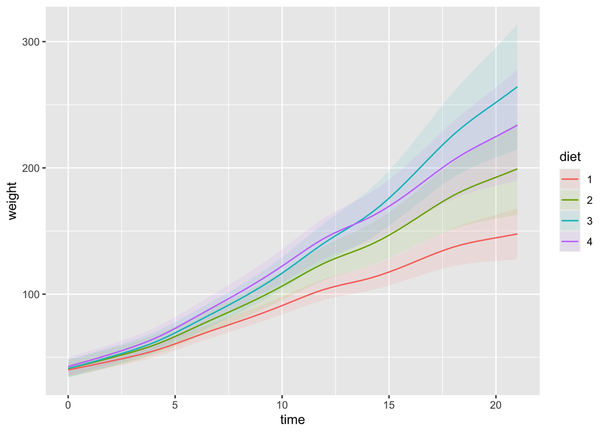

```r
m_cw_fs |>
  plot_predictions(
    condition = c("time", "diet"),
    exclude = "s(time,chick)"
  )
```

Note that in both cases we are setting the random terms to 0 using the `exclude` mechanism. As these models are conditional models, what we get here are estimates of treatment effects for the average subject, *not* population level effects. This is the same as with any GLMM. To get a marginal interpretation, we would need to integrate (average over) the random effect terms.